# Climate Projection Datasets

## Summary Description

Climate projection datasets are collections of outputs from climate models that simulate the climate of the past as well as future climate conditions. Future simulations are based on future greenhouse gas emissions scenarios. These datasets are used to assess potential impacts of climate change on various sectors, including agriculture, water resources, energy systems or ecosystems. Most climate projection datasets presented in this guide have been bias-adjusted to account for systematic deviations of the simulations from observed climatology. The strengths and limitations discussed on this page refer to these bias-adjusted datasets. See CMIP6 and CORDEX for strengths and limitations of the raw datasets that serve as input for bias-adjusted datasets.

## Global Climate Models

Climate models represent the natural processes of the Earth based on physical principles of fluid dynamics and thermodynamics, broken down onto three-dimensional grids to represent interactions of terrain, atmosphere, ice, water, and vegetation (lithosphere, atmosphere, cryosphere, hydrosphere, biosphere). Global climate models (GCMs) or Earth system models (ESMs) can be interpreted as numerical replicas of planet Earth built to generate sequences of global atmospheric circulation and weather events. The resulting time series do not and are not meant to reproduce historical weather sequences or events. They are distinct from the observed record of weather events of the real world but reproduce well long-term climate and its evolution on Earth. Climate models are often used to simulate the response of climate to variations in external forcing, i.e. processes external to the climate that drive changes in the Earth’s energy balance. Exploring the Earth system’s response to changes in external forcing due to increasing greenhouse gas (GHG) concentrations in the atmosphere is the most prominent application of GCMs.

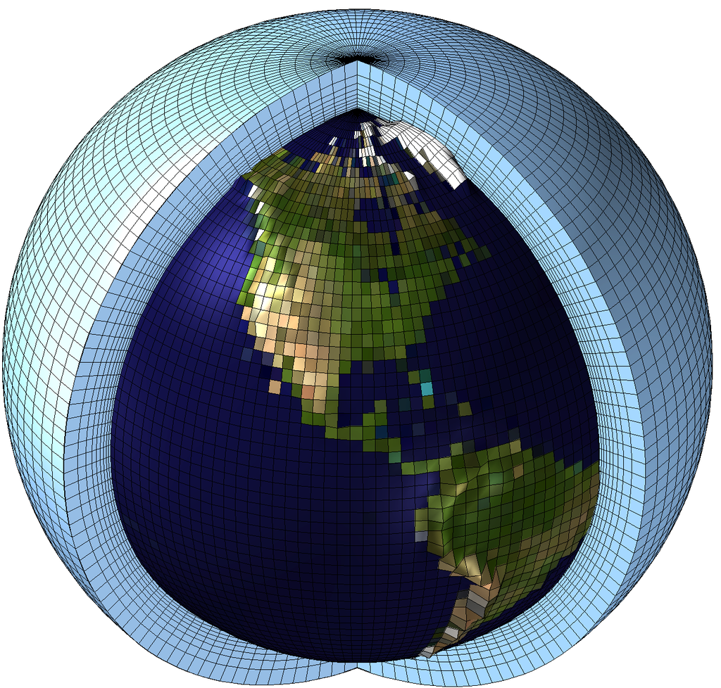

Conceptual visualisation of a Global Climate Model (GCM)

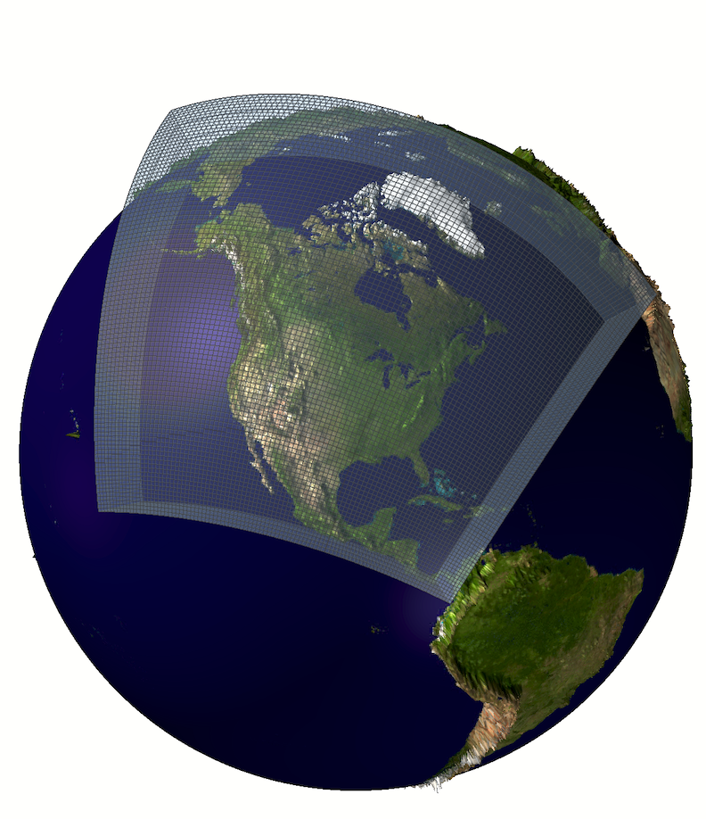

Conceptual visualisation of a Regional Climate Model (RCM) over North America

## Regional Climate Models

Any region’s climate is inevitably linked to the global atmospheric circulation, therefore any simulation with a Regional climate model (RCMs) requires information about atmospheric conditions at its boundaries. Within a regional domain, RCMs operate on the same principles as GCMs; however, they are limited to smaller geographical regions. The conditions at the regions boundaries are taken from GCM simulations or global reanalysis of observational data to drive a regional model. With their smaller spatial coverage, RCM simulations can be run at higher spatial resolution than GCM simulations, thus providing added value where small-scale features impact local climate, such as mountains or coastlines. The process of running an RCM with the input from a driving GCM is often referred to as “dynamical downscaling,” since the higher spatial resolution output from the RCM is intrinsically tied to the coarser driving data. Generations of ensembles of RCM simulations become available later than the GCM simulations, as they depend on the latter as their driving data. Hence, a CMIP generations data from GCMs are published first, followed by those from RCMs. Usually, RCMs will be driven by a relatively small subset of available GCM simulations, which modifies RCM ensemble characteristics compared to GCM ensembles. A regions RCM ensemble will be defined by a combination of RCMs and GCMs which can be represented as a matrix. The [North America CORDEX-CMIP5 simulation matrix](https://na-cordex.org/simulation-matrix.html) provides an example of such an ensemble based on the GCMs modeling centers selected to drive their RCM(s).

## Strengths and Limitations

### Key Strengths of bias-adjusted datasets

| Strength | Description |
| --- | --- |
| **High spatial resolution** | Resolves effects of regional topography and local climate patterns better than GCMs. |
| **Supports impact studies** | Designed to be used for vulnerability, impact, and adaptation (VIA) studies. |
| **Adjustement of biases** | Some of GCM’s biases are sustantially reduced. |

### Key Limitations of bias-adjusted datasets

| Limitation | Description |
| --- | --- |
| **Reference bias** | Biases present in the reference dataset will also appear in bias-adjusted datasets. |
| **Biases remain** | Bias-adjustment cannot completely remove all biases. Different methods will target different characteristics of a dataset. |
| **No-physics at the small scale** | The fine resolution information only come from the reference and not a physical simulation of the future. |
| **Bias stationnarity** | Bias-adjustment assumes that the bias are constant over time. |

## Expert Guidance

For guidance on using climate projection data see the section on core concepts of climate science and analysis Climate: Core Concepts.